# Prediction Assignment Writeup

Servet Demir

06 10 2019

# A- General Summary

This document is the final report of the Peer Assessment project from Coursera’s course Practical Machine Learning, as part of the Specialization in Data Science. It was built in RStudio, using its knitr functions, meant to be published in html format. This analysis meant to be the basis for the course quiz and a prediction assignment writeup. The main goal of the project is to predict the manner in which 6 participants performed some exercise as described below. This is the “classe” variable in the training set. The machine learning algorithm described here is applied to the 20 test cases available in the test data and the predictions are submitted in appropriate format to the Course Project Prediction Quiz for automated grading.

## Explanation About Data

The training data for this project are available here:  
https://d396qusza40orc.cloudfront.net/predmachlearn/pml-training.csv  
The test data are available here:  
https://d396qusza40orc.cloudfront.net/predmachlearn/pml-testing.csv  
The data for this project come from this source: http://groupware.les.inf.puc-rio.br/har.

# B- Data Loading and Explotary Analysis

## B.1. Related Package

```r
library(caret)
```

```r
library(rpart)
library(rpart.plot)
library(randomForest)
library(rattle)
```

## B.2.Data Loading and Cleaning Data

```r
url1 <- "https://d396qusza40orc.cloudfront.net/predmachlearn/pml-training.csv"
url2 <- "https://d396qusza40orc.cloudfront.net/predmachlearn/pml-testing.csv"
if(!file.exists("pml-training.csv")) {
   pml-training <-  download.file(url1, "pml-training.csv")
}
if(!file.exists("./data/pml-testing.csv")) {
    pml-testing <- download.file(url2, "./data/pml-testing.csv")
}
traindata <- read.csv("./data/pml-training.csv", na.strings=c("NA","#DIV/0!",""))
testdata <- read.csv("./data/pml-testing.csv", na.strings=c("NA","#DIV/0!",""))
dim(traindata)
```

```
## [1] 19173   160
```

## B.3. Explanation About Data Variables

Datasets have 160 variables. According explanation (http://groupware.les.inf.puc-rio.br/har), there are three tool to measure “gyroscope”, “accelerator”, “magnet”, also they can be in four position on body[“belt”, “arm”, “dumbbell”, “forearm”] and there are three dimensional measurement “x”, “y”, “z”. When I examine the names of variables related to these measurements, I saw for example “magnet_forearm_x” and “accel_dumbbell_z”, so I produced list variable for analysis.

```r
listtool <- c("gyros", "accel", "magnet") # List for tool
listbodyPos <- c("belt", "arm", "dumbbell", "forearm") # list for body position
listdim <- c("x", "y", "z") # list for dimention
listvariable <- NULL
for (i in listtool) {
        for (n in listbodyPos) {
                for ( m in listdim) {
                        listvariable <- c( listvariable, paste(i,n,m, sep = "_"))
                }
        }
}

listvariable <- c(listvariable, "classe") # Also I add Y variable
listvariable
```

```
##  [1] "gyros_belt_x"      "gyros_belt_y"      "gyros_belt_z"
##  [4] "gyros_arm_x"       "gyros_arm_y"       "gyros_arm_z"
##  [7] "gyros_dumbbell_x"  "gyros_dumbbell_y"  "gyros_dumbbell_z"
## [10] "gyros_forearm_x"   "gyros_forearm_y"   "gyros_forearm_z"
## [13] "accel_belt_x"      "accel_belt_y"      "accel_belt_z"
## [16] "accel_arm_x"       "accel_arm_y"       "accel_arm_z"
## [19] "accel_dumbbell_x"  "accel_dumbbell_y"  "accel_dumbbell_z"
## [22] "accel_forearm_x"   "accel_forearm_y"   "accel_forearm_z"
## [25] "magnet_belt_x"     "magnet_belt_y"     "magnet_belt_z"
## [28] "magnet_arm_x"      "magnet_arm_y"      "magnet_arm_z"
## [31] "magnet_dumbbell_x" "magnet_dumbbell_y" "magnet_dumbbell_z"
## [34] "magnet_forearm_x"  "magnet_forearm_y"  "magnet_forearm_z"
## [37] "classe"
```

Now 36 predictor. Let’s tidy data for analysis and select train and test data. I select variables from listvariable

```r
straining <- traindata[,listvariable] # selection related variables
straining <- na.omit(straining)
set.seed(1234)
inTrain  <- createDataPartition(y=straining$classe, p=0.7, list=FALSE) # Devide data train and test
training <- straining[inTrain, ]
testing  <- straining[-inTrain, ]
dim(training)
```

```
## [1] 13422    37
```

# C. Prediction Model

I will check three model first one is Random Forest, second one is Generalized Boosted Model and third one is Decision Tree

## C.1. Prediction Random Forest

```r
controlRF <- trainControl(method="cv", number=3, verboseIter=FALSE)
model1 <- train(classe~., data=training, method="rf", trControl=controlRF)
model1$finalModel
```

```
##
## Call:
##  randomForest(x = x, y = y, mtry = param$mtry)
##                Type of random forest: classification
##                      Number of trees: 500
## No. of variables tried at each split: 2
##
##         OOB estimate of  error rate: 1.46%
## Confusion matrix:
##      A    B    C    D    E class.error
## A 3897    3    2    3    1 0.002304147
## B   45 2591   22    0    0 0.025206922
## C    3   26 2367    0    0 0.012103506
## D    4    0   69 2176    3 0.033747780
## E    0    3    6    6 2195 0.006787330
```

Calculate accuracy on testing data for RF

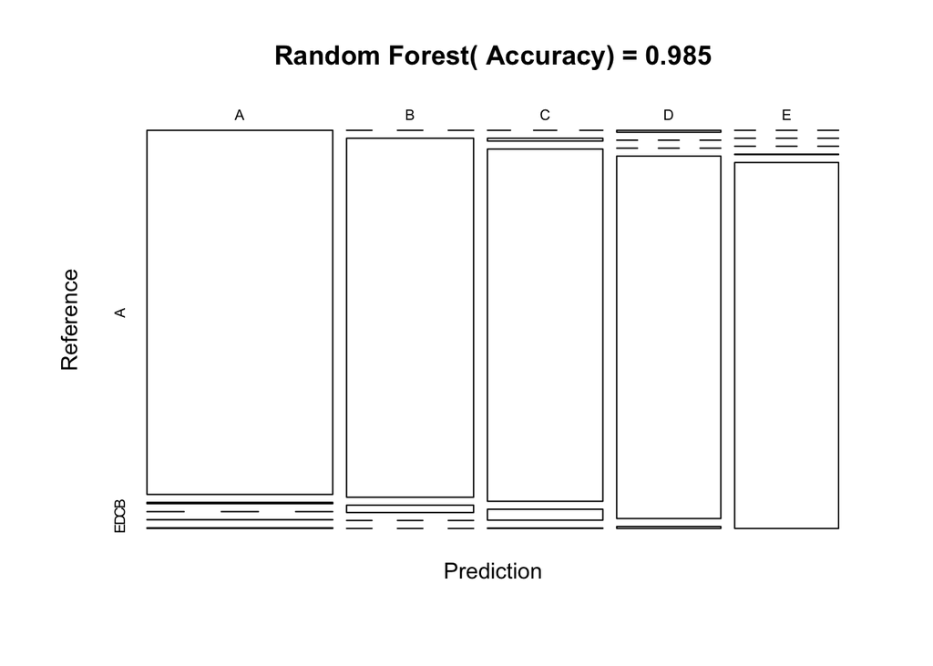

```r
predmodel1 <- predict(model1, testing)
model1ConMatrix <- confusionMatrix(predmodel1, testing$classe)
plot(model1ConMatrix$table, col = model1ConMatrix$byClass, main = paste("Random Forest( Accuracy) =", round(model1ConMatrix$overall['Accuracy'], 3)))
```

For Random forest Model accuracy is 0.985 so it is realy high

## C.2. Prediction Generalized Boosted Model

```r
ControlGBM <- trainControl(method="repeatedcv", number=5, repeats=1)
model2 <- train(classe~., data=training, method="gbm", trControl=ControlGBM, verbose=FALSE)
model2$finalModel
```

```
## A gradient boosted model with multinomial loss function.
## 150 iterations were performed.
## There were 36 predictors of which 36 had non-zero influence.
```

Calculate accuracy on testing data for GBM

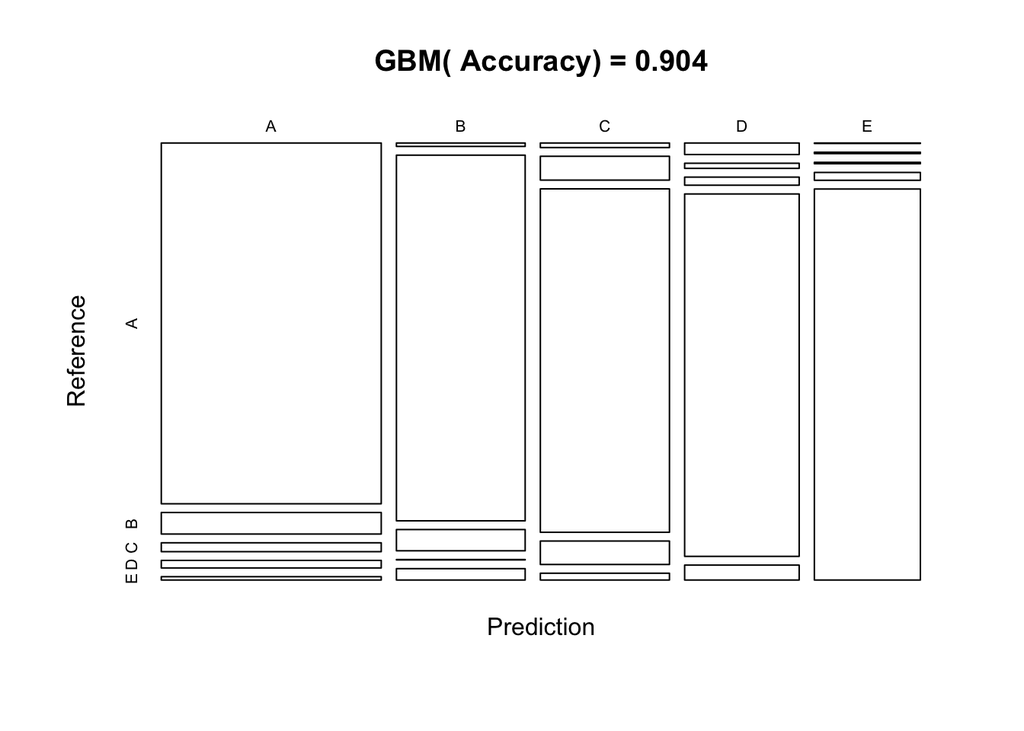

```r
predmodel2 <- predict(model2, testing)
model2ConMatrix <- confusionMatrix(predmodel2, testing$classe)
plot(model2ConMatrix$table, col = model2ConMatrix$byClass, main = paste("GBM( Accuracy) =", round(model2ConMatrix$overall['Accuracy'], 3)))
```

For Generalized Boosted Model accuracy is 0.904

## C.3. Prediction Decision Tree

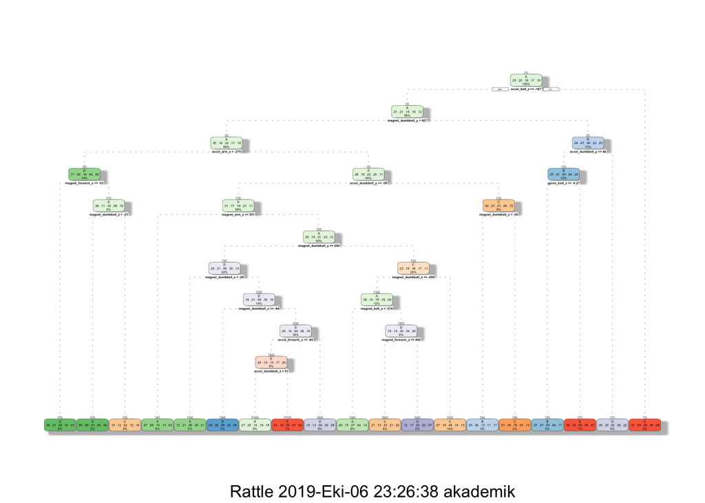

```r
model3 <- rpart(classe ~ ., data=training, method="class")
fancyRpartPlot(model3)
```

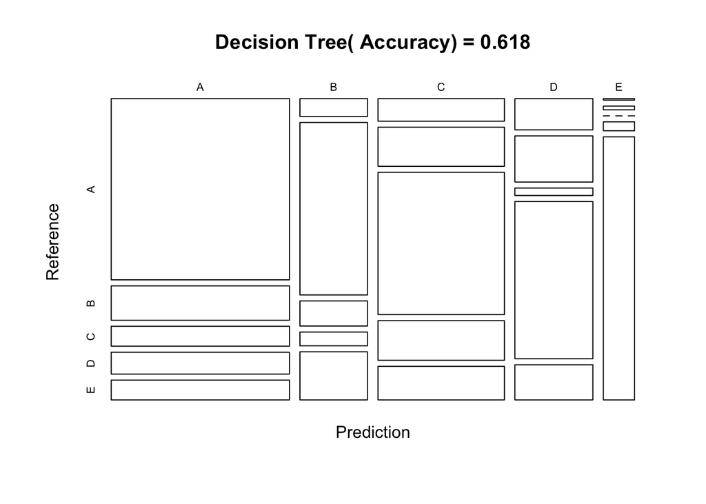

```r
predmodel3 <- predict(model3, testing, type = "class")
model3ConMatrix <- confusionMatrix(predmodel3, testing$classe)
plot(model3ConMatrix$table, col = model3ConMatrix$byClass, main = paste("Decision Tree( Accuracy) =", round(model3ConMatrix$overall['Accuracy'], 3)))
```

For Decision Tree Model accuracy is 0.618

# E. Selectin Model

According to accuracy model1 (Random Forest) is selected. Now Let’s apply prediction to test data

```r
predtest <- predict(model1, testdata)
predtest
```

```
##  [1] B A B A A E D B A A B C B A E E A B B B
## Levels: A B C D E
```

## Final Comment

We can predict human activity with 36 variables which contain the measurement of “gyroscope”, “accelerator”, “magnet”.